# 5(a). Simple Exponential Smoothing

Ankit

1/31/2019

### Simple Exponential Smoothing :-

Simple exponential smoothing method is suitable for the data that do not have any clear trend or seasonality. For eg. Annual oil production in Saudi Arabia

```r
library(fpp2)
```

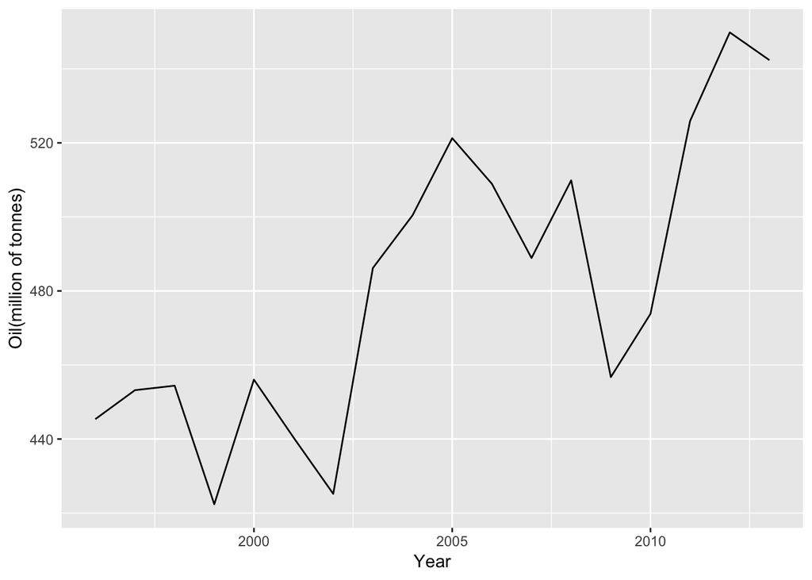

```r
oildata <- window(oil, start = 1996)
autoplot(oildata) +
  xlab("Year") + ylab("Oil(million of tonnes)")
```

The above timeplot do not shows any clear trending behaviour or seasonality. However, there is a rise in last few years that might suggest a trend. Average and Naive method are some simple forecasting methods that can be applied to this kind of data.

Using the Naive method, all future forecasts are equal to the last observed value of the series,
$$\hat y_{T+h|T} = y_T, for h = 1,2,3....$$
This can be thought of as a weighted average where all the weights are given to the last observations.

Using the average method, all future forecasts are the average of all the available observations.
$$\hat y_{T+h|T} = \frac{1}{T} \sum_{t = 1}^{T} y_t,$$
Hence, the average is giving all the observations equal weights.

Simple exponential smoothing works in between these 2 methods. It attches larger weights to more recent observations than to the observations in distant past. Forecasts are calculated using weighted averages, where the weights decrease exponentially as observations come from further in the past.

$$\hat y_{T+h|T} = αy_T + α(1-α)y_{T-1} + α(1-α)^2 y_{T-2} +......, where \ 0\leα\le1$$
α is called the smoothing parameter. The rate at which the weights decrease is controlled by parameter α.

If α is small then we are giving more weights to observations in distant past. If α is large (closer to 1), then more weight is given to more recent observations. For α = 1, the forecasts are equal to naive forecasts.

Let the first fitted value be denoted by $l_o$. The forecast at time T+1 is equal to the weighted average of the most recent observation $y_T$ and the previous forecast $\hat y_{T|T-1}$.
$$\hat y_{T+1|t} = αy_t + (1-α) \hat y_{T|T-1},$$
Substituting the value of forecasts, we can drive to
$$\hat y_{T+1|T} = \sum_{j =0}^{T-1}α(1-α)^jy_{T-j} + (1-α)^Tl_o$$
This is called **Weighted Average Form**.

#### Component Form :-

Component form representations of exponential smoothing methods comprise a forecast equation and a smoothing equation for each of the components included in the method. For simple exponential smoothing, the only component included is the level.

**Forecast Equation :-** $\hat y_{t+h|t} = l_t$.

**Smoothing equation :-** $l_t = αy_t + (1-α)l_{t-1}$.

where $l_t$ will gives us the level of the time series at time t. Setting h = 1 gives the fitted values, while setting t = T gives the true forecasts beyond the training data.

Simple exponential smoothing has a “flat” forecast function. That is, all forecasts take the same value, equal to the last level component.

#### Optimisation :-

The application of exponential smoothing requires the smoothing paramters and the initial value to be choosen(α and $l_o$).

The unknown paramters and the initial value of the exponential smoothing can be estimated by minimising SSE.
$$SSE = \sum_{t = 1}^{T}(y_t - \hat y_t)^2$$
Now, unlike regression where we have formulas for coefficient that minimise the SSE, this involves a non-linear minimisation problem, and we need to use an optimisation tool to solve it.

```r
oildata = window(oil,start = 1996)

fc = ses(oildata,h =5)
fc$model
```

```
## Simple exponential smoothing
##
## Call:
##  ses(y = oildata, h = 5)
##
##   Smoothing parameters:
##     alpha = 0.8339
##
##   Initial states:
##     l = 446.5868
##
##   sigma:  29.8282
##
##      AIC     AICc      BIC
## 178.1430 179.8573 180.8141
```

This gives the value of α = 0.8339 and initial value to be 446.6.

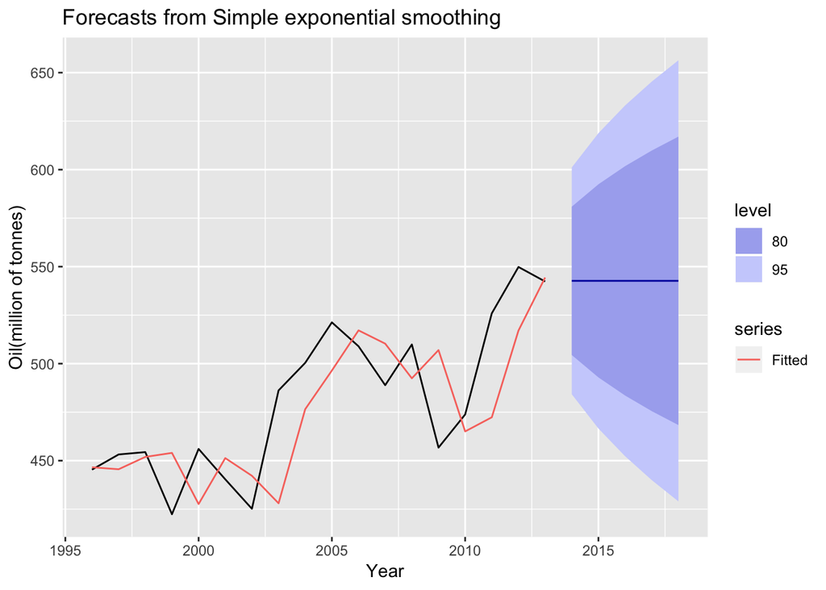

```r
autoplot(fc) +
  autolayer(fitted(fc), series = "Fitted") +
  xlab("Year") + ylab("Oil(million of tonnes)")
```

The large value of α in this example is reflected in the large adjustment that takes place in the estimated level $l_t$ at each time. A smaller value of α would lead to smaller changes over time, and so the series of fitted values would be smoother.

```r
fc
```

```
##      Point Forecast    Lo 80    Hi 80    Lo 95    Hi 95
## 2014       542.6806 504.4541 580.9070 484.2183 601.1429
## 2015       542.6806 492.9073 592.4539 466.5589 618.8023
## 2016       542.6806 483.5747 601.7864 452.2860 633.0752
## 2017       542.6806 475.5269 609.8343 439.9778 645.3834
## 2018       542.6806 468.3452 617.0159 428.9945 656.3667
```

We can also see that the prediction are very high in this case which shows there is considerable uncertainity in the future oil value.

##### Excercise

**1. No. of pigs slaughtered in Victoria each month.**

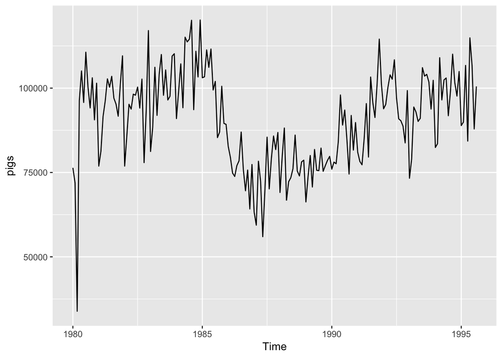

```r
autoplot(pigs)
```

```r
pigs_forc = ses(pigs, h = 4)
pigs_forc$model
```

```
## Simple exponential smoothing
##
## Call:
##  ses(y = pigs, h = 4)
##
##   Smoothing parameters:
##     alpha = 0.2971
##
##   Initial states:
##     l = 77260.0561
##
##   sigma:  10308.58
##
##      AIC     AICc      BIC
## 4462.955 4463.086 4472.665
```

The data do not show any trend or seasonal pattern. We have applied exponential smoothing method. The value of alpha is 0.2971. A smaller value of alpha shows that higher weight is given to past observations.

```r
pigs_forc
```

```
##          Point Forecast    Lo 80    Hi 80    Lo 95    Hi 95
## Sep 1995       98816.41 85605.43 112027.4 78611.97 119020.8
## Oct 1995       98816.41 85034.52 112598.3 77738.83 119894.0
## Nov 1995       98816.41 84486.34 113146.5 76900.46 120732.4
## Dec 1995       98816.41 83958.37 113674.4 76092.99 121539.8
```

95% confidence interval of first forecast

```r
#Manually
print(c("lower limit" , pigs_forc$mean[1] - 1.96 * sd(residuals(pigs_forc))))
```

```
## [1] "lower limit"      "78679.9672534162"
```

```r
print(c("upper limit",pigs_forc$mean[1] + 1.96 * sd(residuals(pigs_forc))))
```

```
## [1] "upper limit"      "118952.844969765"
```

The CI calculated is close to the one calculated by R.

**2. Function for simple exponential smoothing**

```r
Ses_f <- function(y, alpha, level){
  forc = (1-alpha)^(length(pigs)) * level
  for (i in (length(pigs)-1):0) {
    forc = forc + alpha*(1-alpha)^i * pigs[length(pigs)-i]
  }
  return(forc)
}
# Check if the function gives the same result as the ses function.
Ses_f(pigs, 0.2971, 77260.0561)
```

```
## [1] 98816.45
```

The results from the user defined function and ses function are approximately same.

**3. Function to return sum of squared error**

```r
Ses_err <- function(param,y){
  alpha = param[1]
  level = param[2]
  pred = vector(length = length(y))
  pred[1] = level
  SSE = (pigs[1] - pred[1])^2
  for (i in 2:length(y)) {
    pred[i] = alpha * y[i-1] + (1 - alpha) * pred[i-1]
    SSE = SSE + (y[i] - pred[i])^2
  }
  return(SSE)
}

optim(c(1,pigs[1]), fn = Ses_err, y= pigs)
```

```
## $par
## [1] 2.971617e-01 7.726153e+04
##
## $value
## [1] 19765613351
##
## $counts
## function gradient
##      143       NA
##
## $convergence
## [1] 0
##
## $message
## NULL
```

The value of alpha and level from optim function are close to the ses function.

**4. Construting the ses function**

```r
SES <- function(data){
  param = optim(c(1,data[1]), fn = Ses_err, y= data)$par
  forecast = Ses_f(data, param[1], param[2])
  forc = list(param[1], param[2], forecast)
  names(forc) <- c("alpha", "level", "1st forecast")
  return(forc)
}

SES(pigs)
```

```
## $alpha
## [1] 0.2971617
##
## $level
## [1] 77261.53
##
## $`1st forecast`
## [1] 98816.39
```

**5. Daily Sales of paperback and hardcover books**

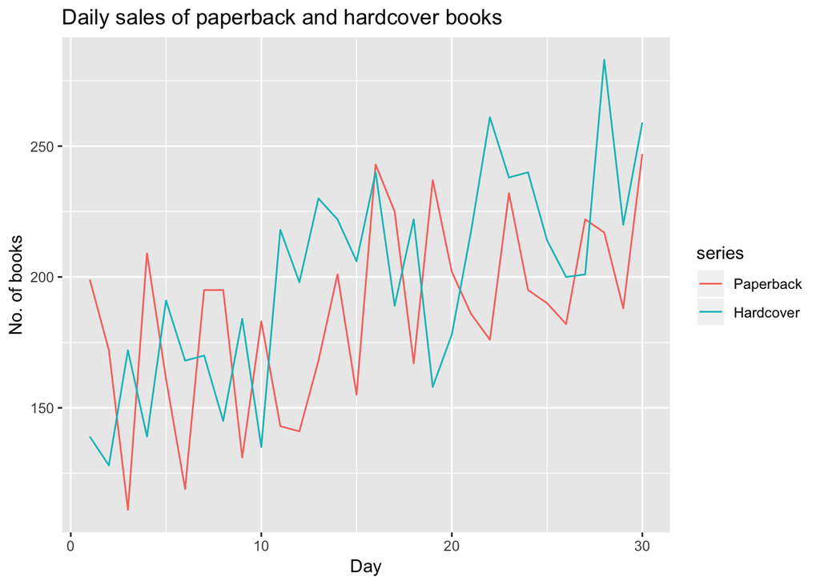

```r
autoplot(books) + xlab("Day") +
  ylab("No. of books") + ggtitle("Daily sales of paperback and hardcover books")
```

The 2 series seems to have an increasing trend but no seasonality present.

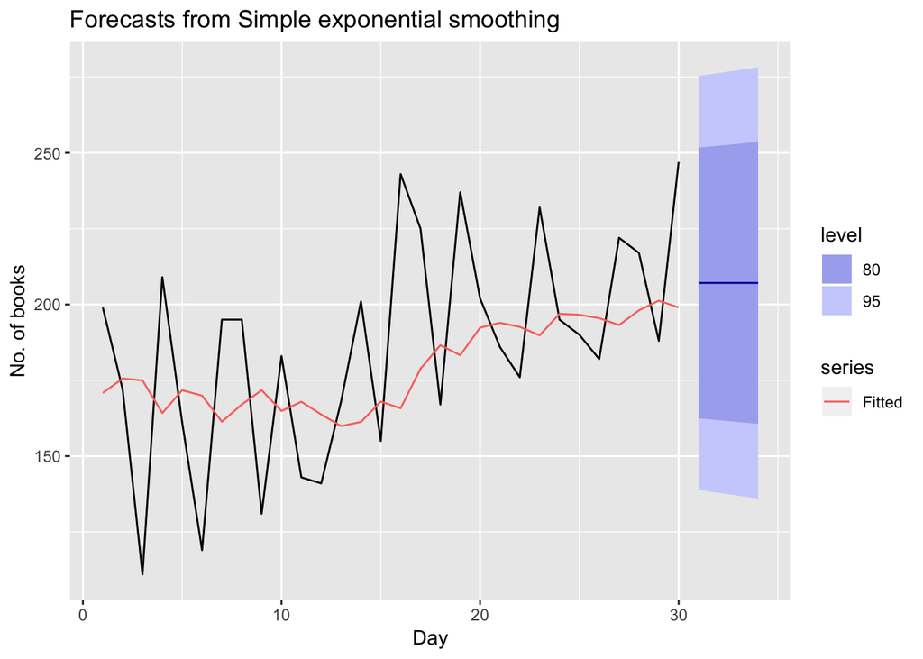

```r
fc_pb = ses(books[,1], h = 4)
autoplot(fc_pb) +
  autolayer(fitted(fc_pb), series = "Fitted") +
  xlab("Day") +
  ylab("No. of books")
```

```r
print(c("RMSE",sqrt(mean((books[,1] - fitted(fc_pb))^2))))
```

```
## [1] "RMSE"            "33.637686782912"
```

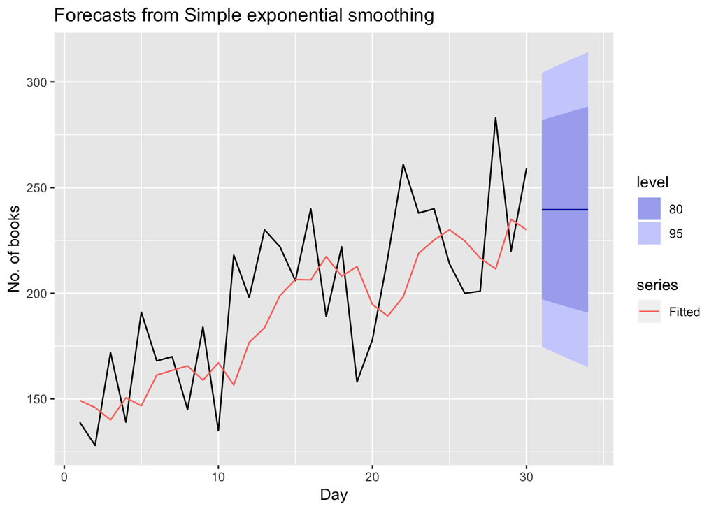

```r
fc_hc = ses(books[,2], h = 4)
autoplot(fc_hc) +
  autolayer(fitted(fc_hc), series = "Fitted") +
  xlab("Day") +
  ylab("No. of books")
```

```r
print(c("RMSE",sqrt(mean((books[,2] - fitted(fc_hc))^2))))
```

```
## [1] "RMSE"             "31.9310149844547"
```

The 2 methods showing high error because we are not considering trend in the data which is an incorrect assumption in this case.